# PCA

Dmitrii Sazykin

## BlueJays

Данные – размеры синих соек.

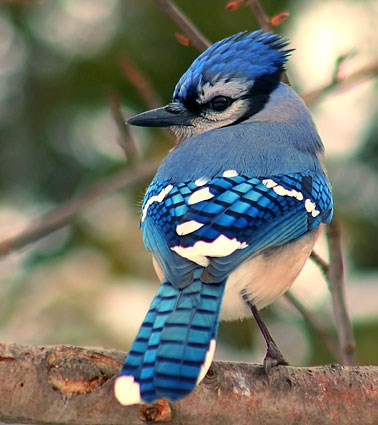

Признаки:

```r
names(df)
```

```
## [1] "BillDepth"  "BillWidth"  "BillLength" "Head"       "Mass"
## [6] "Skull"      "Sex"
```

- BillDepth – Глубина ноздри (мм)
- BillWidth – Ширина клюва (мм)
- BillLength – Длина клюва (мм)
- Head – Расстояние от кончика клюва до затылка (мм)
- Mass – Вес тела (г)
- Skull – Обхват черепа (мм)
- Sex – Пол птички (0 == female, 1 == male)

Краткий обзор данных:

```r
describe(df, fast=T)
```

```
##            vars   n  mean   sd   min   max range   se
## BillDepth     1 123  8.23 0.39  7.21  9.00  1.79 0.04
## BillWidth     2 123  9.22 0.53  8.00 10.82  2.82 0.05
## BillLength    3 123 24.84 1.18 22.25 30.00  7.75 0.11
## Head          4 123 55.69 1.57 51.60 60.67  9.07 0.14
## Mass          5 123 71.56 4.77 58.80 81.50 22.70 0.43
## Skull         6 123 30.86 0.92 28.82 33.30  4.48 0.08
## Sex           7 123  0.51 0.50  0.00  1.00  1.00 0.05
```

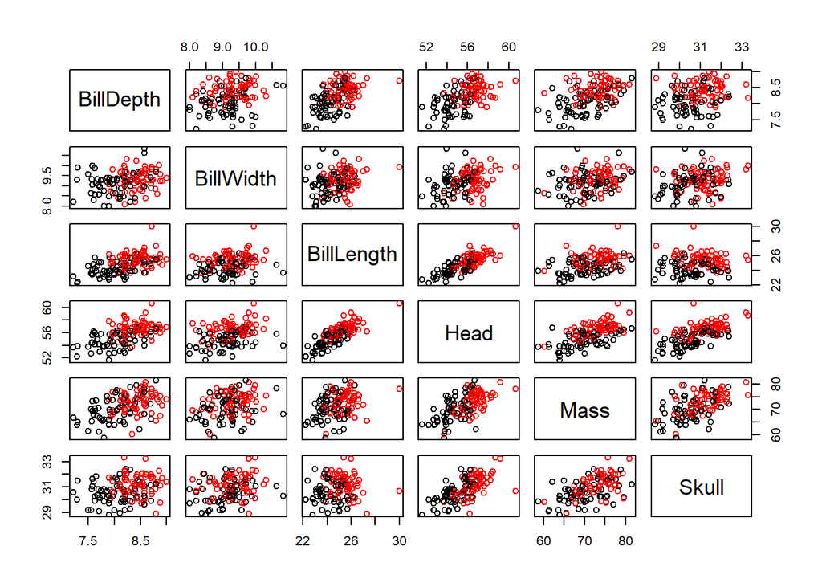

Красным выделены мальчики, черным – девочки.

```r
cr <-  cor(df[,-7])
print(cr , digits = 2)
```

```
##            BillDepth BillWidth BillLength Head Mass Skull
## BillDepth       1.00      0.27       0.55 0.56 0.47  0.25
## BillWidth       0.27      1.00       0.30 0.36 0.29  0.24
## BillLength      0.55      0.30       1.00 0.81 0.41  0.11
## Head            0.56      0.36       0.81 1.00 0.63  0.67
## Mass            0.47      0.29       0.41 0.63 1.00  0.55
## Skull           0.25      0.24       0.11 0.67 0.55  1.00
```

Все корреляции положительны – сразу можем сказать, что первая компонента будет соответствовать размеру птички.

Можно заметить, что в среднем птички мужского пола больше женского (сравнив среднее в группах и длину доверительного интервала se)

```r
describeBy(df,df$Sex,fast = T,mat = T, digits = 2)
```

```
##             item group1 vars  n  mean   sd   min   max range   se
## BillDepth1     1      0    1 60  8.01 0.37  7.21  8.80  1.59 0.05
## BillDepth2     2      1    1 63  8.44 0.27  7.89  9.00  1.11 0.03
## BillWidth1     3      0    2 60  9.12 0.56  8.00 10.82  2.82 0.07
## BillWidth2     4      1    2 63  9.31 0.49  8.10 10.31  2.21 0.06
## BillLength1    5      0    3 60 24.18 0.97 22.25 26.30  4.05 0.12
## BillLength2    6      1    3 63 25.46 1.01 23.62 30.00  6.38 0.13
## Head1          7      0    4 60 54.65 1.24 51.60 56.84  5.24 0.16
## Head2          8      1    4 63 56.69 1.14 53.74 60.67  6.93 0.14
## Mass1          9      0    5 60 69.81 5.01 58.80 81.50 22.70 0.65
## Mass2         10      1    5 63 73.23 3.87 60.17 80.90 20.73 0.49
## Skull1        11      0    6 60 30.46 0.85 28.82 32.39  3.57 0.11
## Skull2        12      1    6 63 31.23 0.82 28.90 33.30  4.40 0.10
## Sex1          13      0    7 60  0.00 0.00  0.00  0.00  0.00 0.00
## Sex2          14      1    7 63  1.00 0.00  1.00  1.00  0.00 0.00
```

## PCA

Немного теории. Пусть $\mathbf{X}\in \mathrm{R}^{n\times p}$ – матрица данных.

$$\mathbf{X}^\mathrm{T} = \sum_{i=1}^d\sqrt{\lambda_i}U_iV_i^\mathrm{T} = \sum_{i=1}^d F_iV_i^\mathrm{T} = \sum_{i=1}^d U_i Z_i^\mathrm{T},$$
где

1. $U_i$ – матрица поворота, собственные вектора корреляционной матрицы. Интерпретация – коэффициенты линейной комбинации изначальных орт для получения главных компонент;
2. $V_i$ – факторные вектора, нормированные главные компоненты;
3. $F_i$ – факторные веса (нагрузки), $F_i = \sqrt{\lambda_i}U_i$,

$$f_{ij} = <X_i^\mathrm{(c)},V_j > = \widehat{\text{cov}}(X_i^\mathrm{(c)},V_j) ;$$

4. $Z_i$ – главные компоненты, $z_{ij} = <\mathbf{X}^\mathrm{T}_i,U_j>$ – координата i-го индивида в базисе из $\{U_j \}$.

Разберем следующие пакеты для АГК

```r
library("ade4")
```

### ade4 package

Основная функция - ?dudi.pca()

```r
dudi.pca(df, row.w = rep(1, nrow(df))/nrow(df),
    col.w = rep(1, ncol(df)), center = TRUE, scale = TRUE,
    scannf = TRUE, nf = 2)
```

Для начала исключим из анализа признак “Sex”, то есть попробуем найти отличия не между индивидами, а между группами.

```r
pca1 <- dudi.pca(df[,-7],scannf = F, nf=6)
pca1
```

```
## Duality diagramm
## class: pca dudi
## $call: dudi.pca(df = df[, -7], scannf = F, nf = 6)
##
## $nf: 6 axis-components saved
## $rank: 6
## eigen values: 3.246 1.003 0.8072 0.5424 0.4009 ...
##   vector length mode    content
## 1 $cw    6      numeric column weights
## 2 $lw    123    numeric row weights
## 3 $eig   6      numeric eigen values
##
##   data.frame nrow ncol content
## 1 $tab       123  6    modified array
## 2 $li        123  6    row coordinates
## 3 $l1        123  6    row normed scores
## 4 $co        6    6    column coordinates
## 5 $c1        6    6    column normed scores
## other elements: cent norm
```

В старых обозначениях:

1)pca$tab == $\mathbf{X}^\mathrm{(s)}$, стандартизованная матрица;

2)pca$li == $\mathbf{Z}$, главные компоненты;

3)pca$l1 == $\mathbf{V}$, факторные вектора;

4)pca$co == $\mathbf{F}$, факторные нагрузки;

5)pca$c1 == $\mathbf{U}$, матрица поворота.

Рассмотрим матрицу собственных векторов.

```r
pca1$c1
```

```
##                   CS1          CS2         CS3         CS4          CS5
## BillDepth  -0.3969857 -0.342262537 -0.15267580  0.70664985 -0.450105291
## BillWidth  -0.2810408 -0.044926541  0.95822204  0.02838445  0.001569506
## BillLength -0.4209312 -0.544180448 -0.13629166 -0.43921746  0.141941341
## Head       -0.5231576  0.007875712 -0.14075388 -0.40403900 -0.131442872
## Mass       -0.4308880  0.277787878 -0.12517605  0.35651048  0.770973799
## Skull      -0.3561979  0.712374529 -0.06666709 -0.12876761 -0.406912265
##                      CS6
## BillDepth   0.0001782600
## BillWidth   0.0001746131
## BillLength  0.5431849028
## Head       -0.7251949252
## Mass       -0.0002123608
## Skull       0.4231339911
```

Как и ожидалось, все признаки вошли в первую компоненту с одним знаком – первая компонента отвечает за общий размер птички. Во второй компоненте можно заметить, что признаки разделились на размеры тела и размеры клюва – вторая компонента определяет “носатость” птички.

### factoextra

Пакет для визуализации полученных данных.

Основные функции

- get_eigenvalue(res.pca)
- fviz_eig(res.pca)
- get_pca_ind(res.pca), get_pca_var(res.pca)
- fviz_pca_ind(res.pca), fviz_pca_var(res.pca)
- fviz_pca_biplot(res.pca)

```r
eig <- get_eigenvalue(pca1)
eig
```

```
##         eigenvalue variance.percent cumulative.variance.percent
## Dim.1 3.246251e+00     5.410418e+01                    54.10418
## Dim.2 1.003333e+00     1.672221e+01                    70.82639
## Dim.3 8.071702e-01     1.345284e+01                    84.27923
## Dim.4 5.423690e-01     9.039484e+00                    93.31871
## Dim.5 4.008756e-01     6.681260e+00                    99.99997
## Dim.6 1.789654e-06     2.982756e-05                   100.00000
```

Тут представлены $\lambda_i$, индивидуальный вклад дисперсии и накопленный вклад дисперсии.

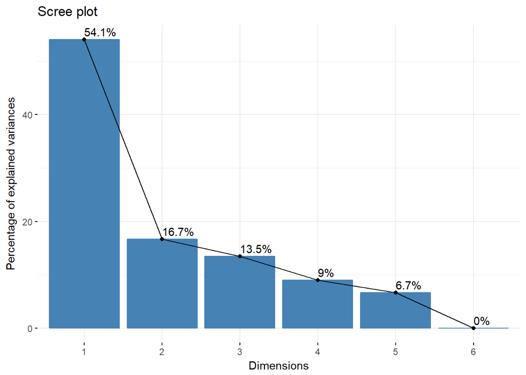

```r
fviz_eig(pca1,addlabels = T)
```

Scree plot, визуализирующий вклад компонент.

Первые две компоненты имеют 70% объясненной дисперсии.

```r
get_pca_var(pca1)
```

```
## Principal Component Analysis Results for variables
##  ===================================================
##   Name       Description
## 1 "$coord"   "Coordinates for the variables"
## 2 "$cor"     "Correlations between variables and dimensions"
## 3 "$cos2"    "Cos2 for the variables"
## 4 "$contrib" "contributions of the variables"
```

С помощью функции get_pca_var можем получить информацию о признаках.

1. $coord – координаты признаков, $\mathbf{F}$, факторные нагрузки;
2. $cor – корреляции между признаками и факорными векторами, в случае стандартизации совпадает с $coord;
3. $cos2 – $\cos^2(X_i,V_j)$, в случае стандартизации есть $\{f_{ij}^2\}$;
4. $contrib – вклад $\cos^2$ i-го признака в j-ю главную компоненту в процентах

$$\text{contrib}_{ij}=100\dfrac{\cos^2(X_i,V_j)}{\sum_{k=1}^p \cos^2(X_k,V_j)} .$$

```r
get_pca_ind(pca1)
```

```
## Principal Component Analysis Results for individuals
##  ===================================================
##   Name       Description
## 1 "$coord"   "Coordinates for the individuals"
## 2 "$cos2"    "Cos2 for the individuals"
## 3 "$contrib" "contributions of the individuals"
```

Аналогично для индивидов.

Визуализируем полученные результаты.

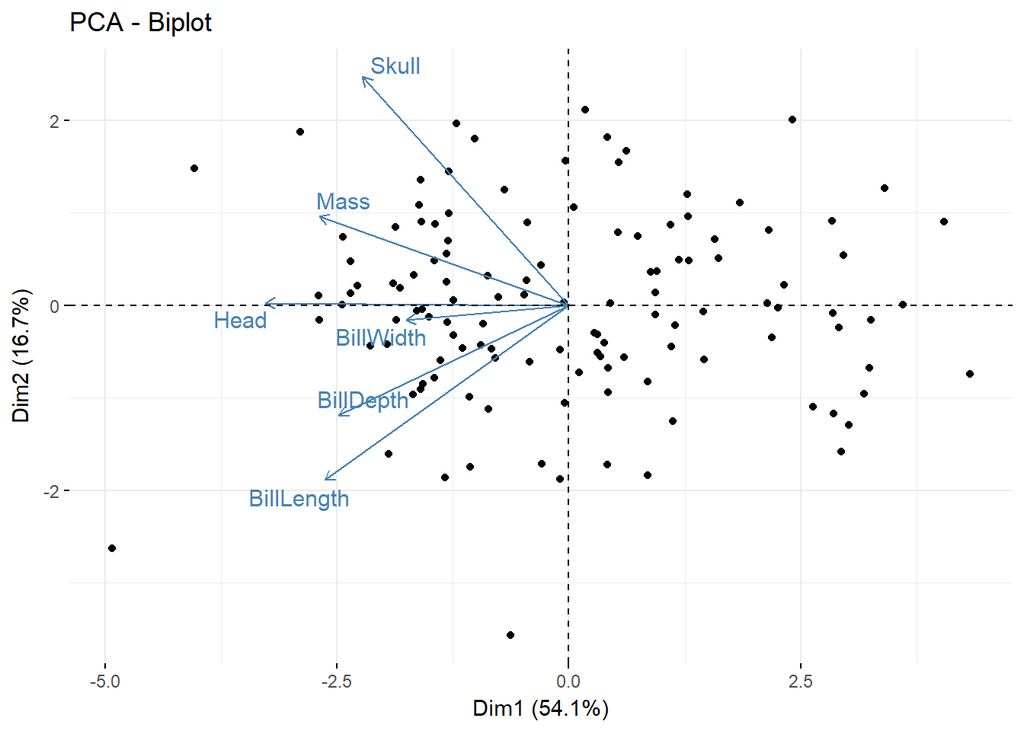

```r
fviz_pca_biplot(pca1, repel = TRUE, label = "var") #8; 74 and 82
```

Синие стрелки – $U_i$, оси есть $Z_i$ (вычисляется по нормировке).

Как и ожидалось – знак всех признаков совпал по первой компоненте, что означает, что в первую очередь птички различаются по размеру. Также можно увидеть несколько выделяющихся наблюдений. Попробуем убрать их.

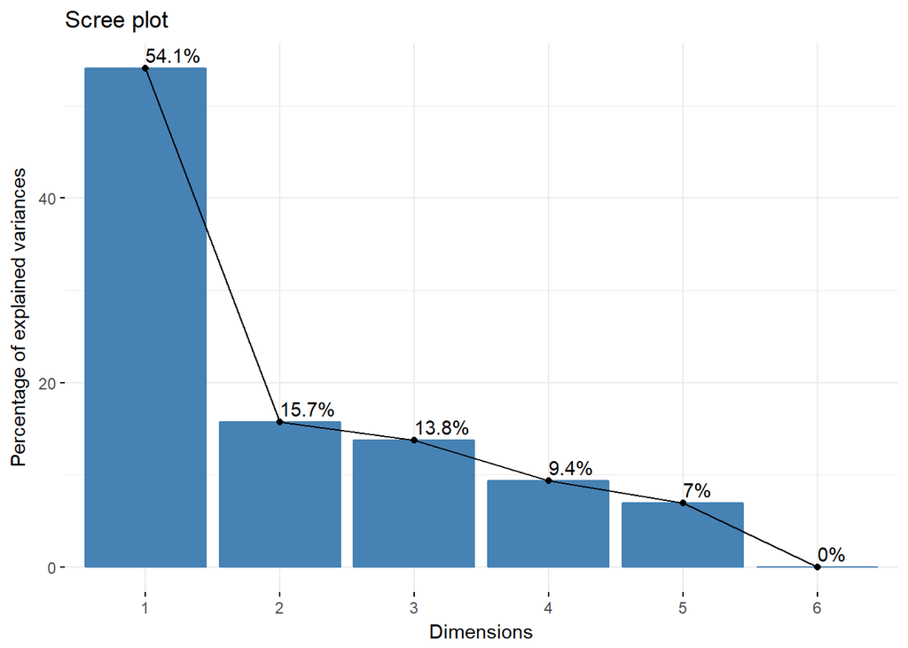

```r
df2 <- df[-c(8,74,82),]
pca2 <- dudi.pca(df2[,-7],scannf = F, nf=6)
fviz_eig(pca2,addlabels = T)
```

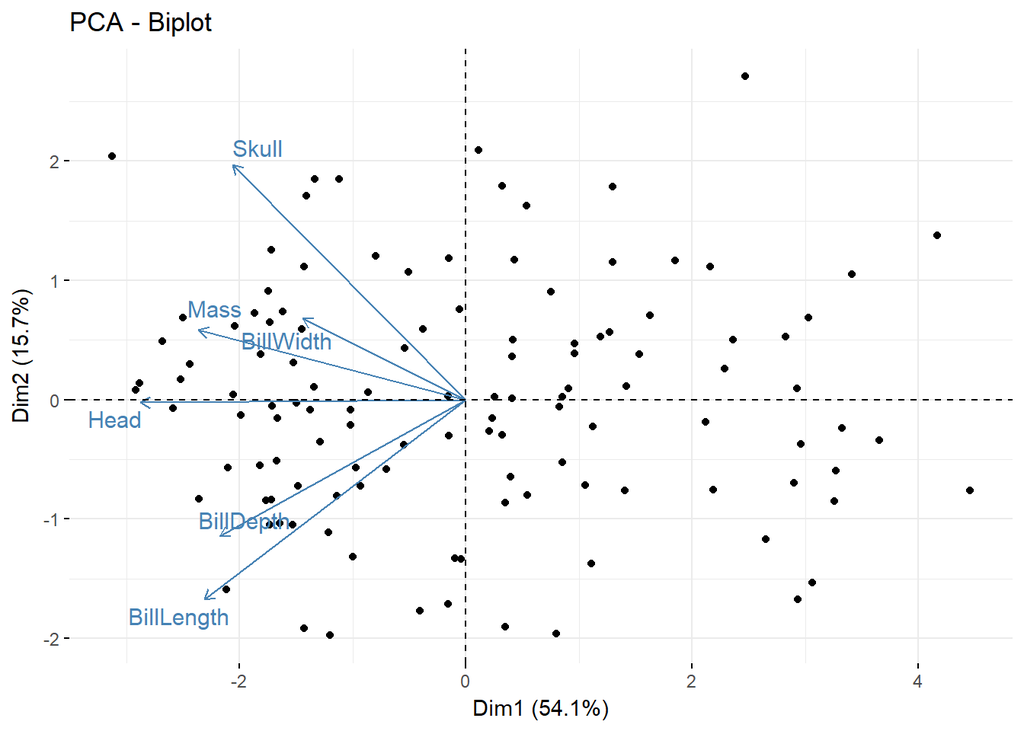

```r
fviz_pca_biplot(pca2, repel = TRUE, label = "var")
```

Можно заметить, что изменилось направление стрелки с признаком “BillWidth”.

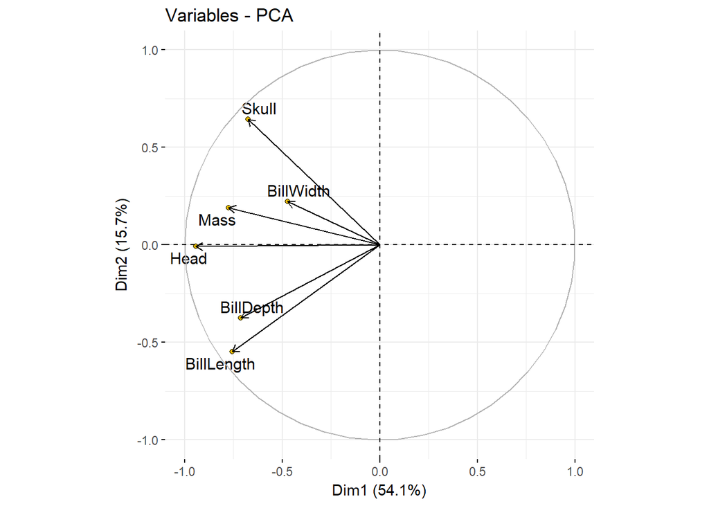

```r
fviz_pca_var(pca2, geom = c("point","arrow","text"),
             pointshape = 21, fill = "#E7B800", repel=T)
```

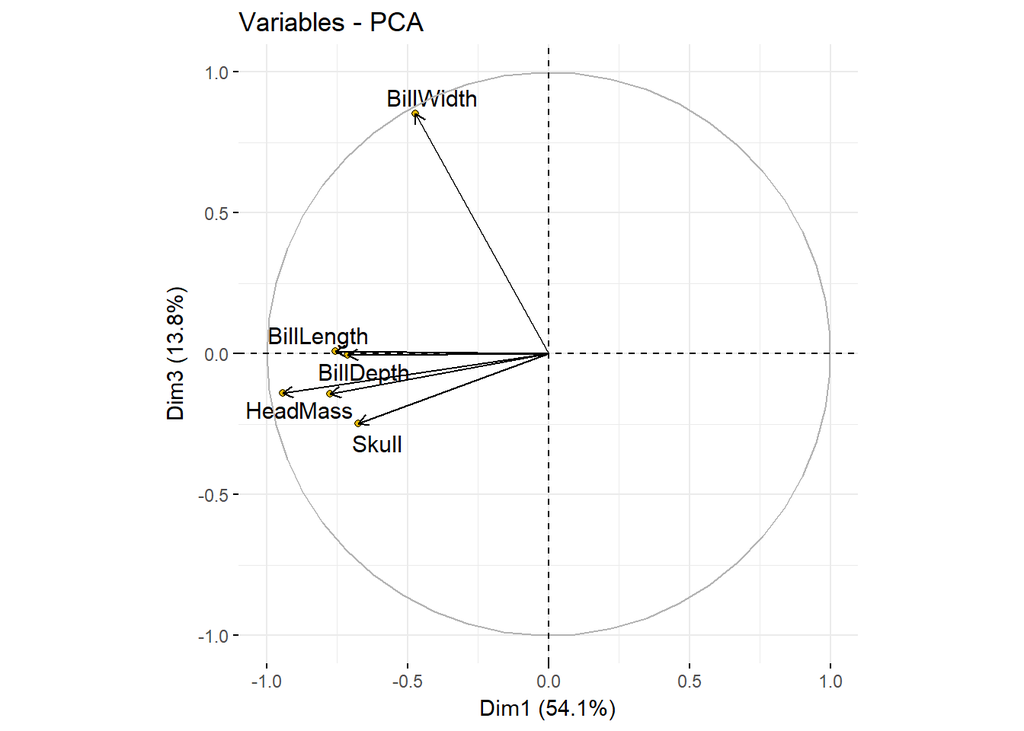

```r
fviz_pca_var(pca2,  geom = c("point","arrow","text"),
             pointshape = 21, fill = "#E7B800", repel=T, axes = c(1,3))
```

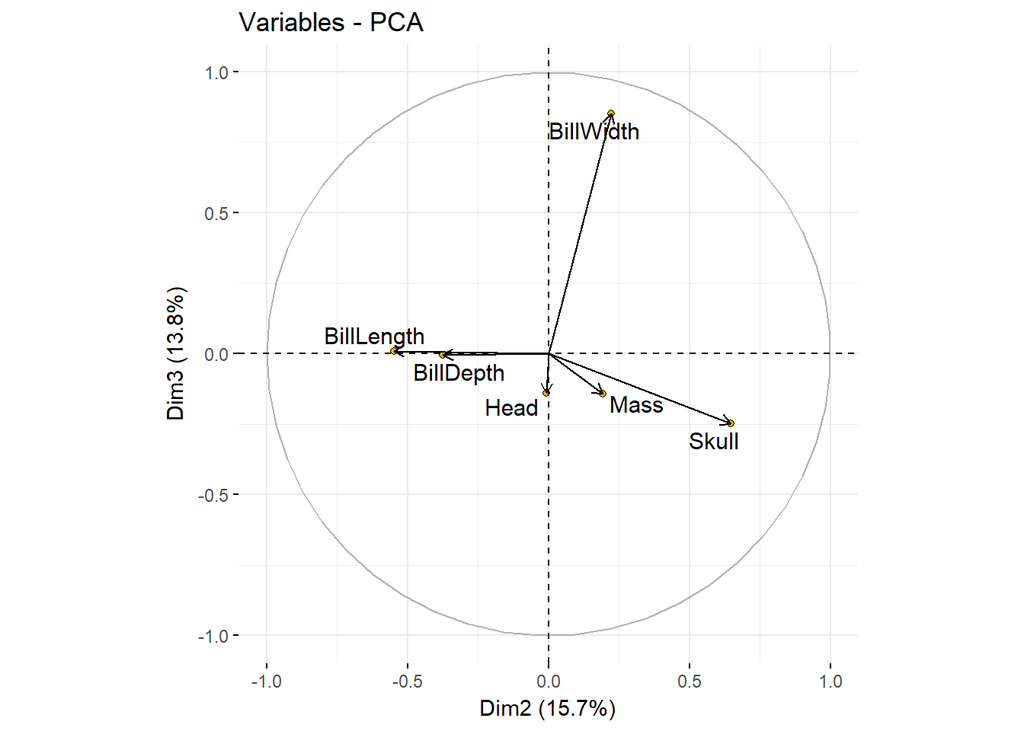

```r
fviz_pca_var(pca2,  geom = c("point","arrow","text"),
             pointshape = 21, fill = "#E7B800", repel=T, axes = c(2,3))
```

Как мы интерпретировали ранее, первая компонента символизирует размер птички. Как оказалось, ширина клюва (BillWidth) практически ортогональна рассматриваемому пространству и практически не вносит вклад в первые две компоненты. Второй признак показывает различие между носом птички и её телом, то есть показывает “носатость” птички.

Как оказалось, третья компонента состоит в основном из ширины клюва BillWidth.

Напомним, что так как сейчас рассматриваются неоднородные данные (птички обоих полов), неоднородные потому что различия в характеристиках значимые, то данные компоненты показывают разницу не между птичками, а между группами.

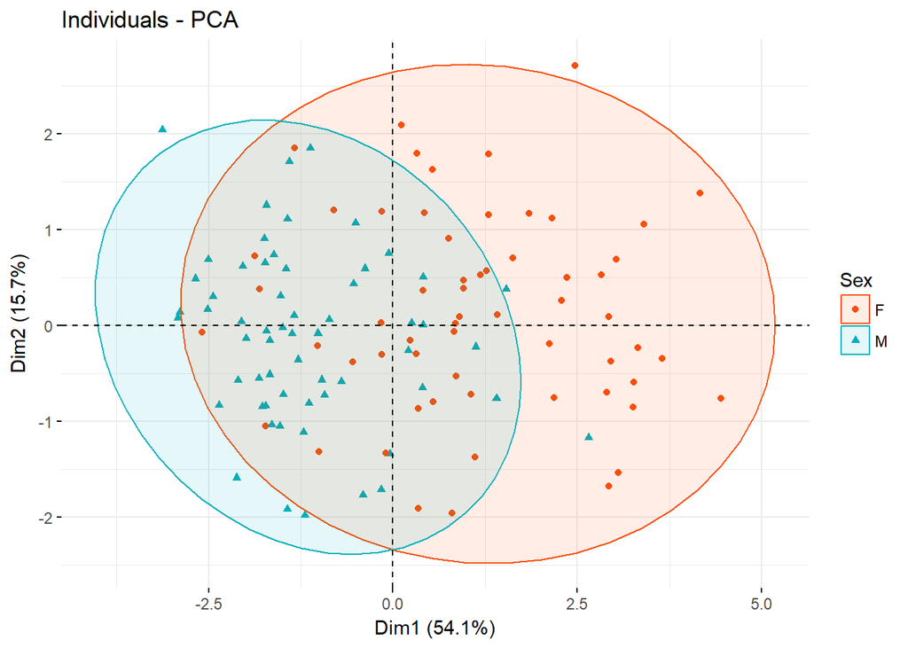

```r
fviz_pca_ind(pca2,
             geom.ind = "point",
             col.ind = BlueJays$KnownSex[-c(8,74,82)], # color by groups
             palette = c("#FC4E07","#00AFBB"),
             addEllipses = TRUE, # Concentration ellipses
             #ellipse.type = "confidence",
             legend.title = "Sex",
             mean.point = FALSE,
             ellipse.level=0.95)
```

Можно убедиться в этом, раскрасив точки (в соответствии с признаком Sex).

В пакете ade4 есть удобные функции для построения графиков с разбиением

```r
s.class(pca2$li,
fac = BlueJays$KnownSex[-c(8,74,82)],  # color by groups
col = c("#FC4E07","#00AFBB"),cellipse = 2.5
)
```

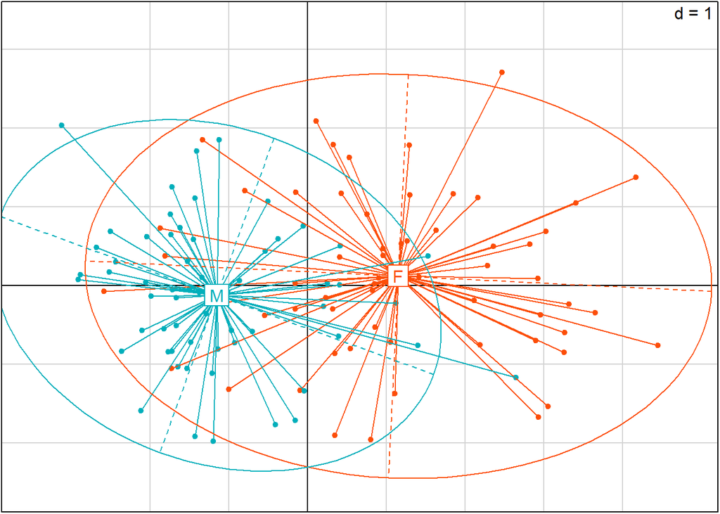

Первая компонента разделяет две группы, среднее в каждой группе лежит на PC1.

Попробуем рассмотреть каждую группу отдельно.

```r
df3 <- subset(df2,Sex == 1,select = -Sex)
pca3 <- dudi.pca(df3[,-7],scannf = F,nf = 6)
df4 <- subset(df2,Sex == 0,select = -Sex)
pca4 <- dudi.pca(df4[,-7],scannf = F,nf = 6)
```

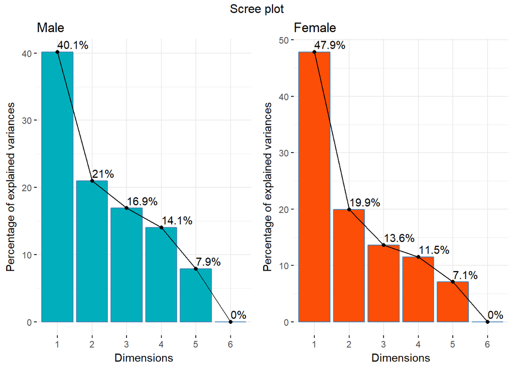

```r
p1 <- fviz_eig(pca3,addlabels = T,title = "Male",barfill="#00AFBB")
p2 <- fviz_eig(pca4,addlabels = T,title = "Female",barfill="#FC4E07")
grid.arrange(p1,p2, ncol=2,top="Scree plot")
```

Вклады компонент в группах похожи, но отличаются от случая, когда мы рассматривали всех птичек вместе, ранее первая компонента объясняла больше дисперсии (54%).

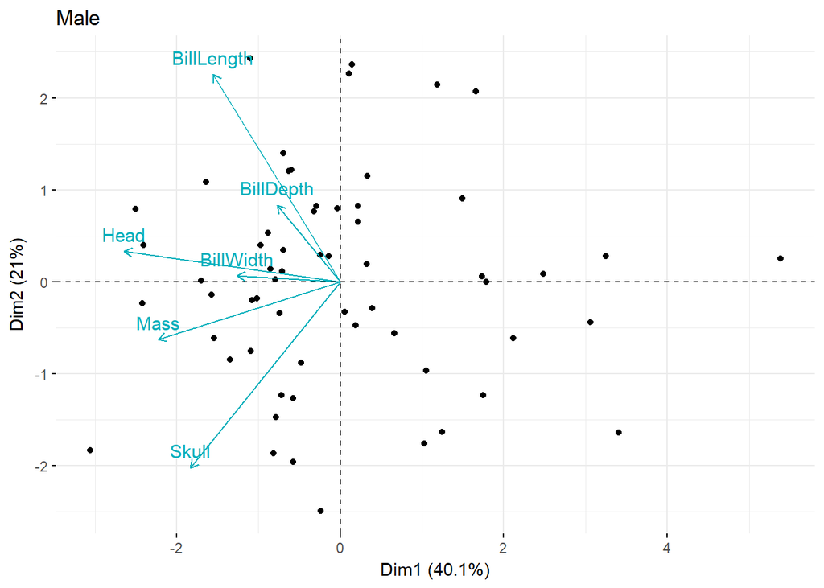

```r
fviz_pca_biplot(pca3,label = "var",title = "Male",col.var = "#00AFBB") #41
```

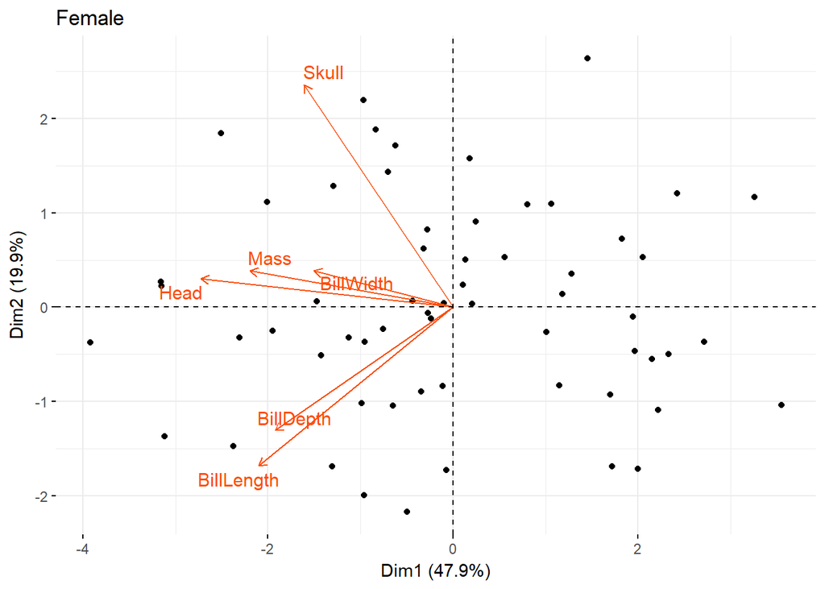

```r
fviz_pca_biplot(pca4, label = "var",title = "Female",col.var = "#FC4E07",repel = T)
```

У мальчиков можно заметить индивида, выделяющегося по первой компоненте, попробуем убрать его.

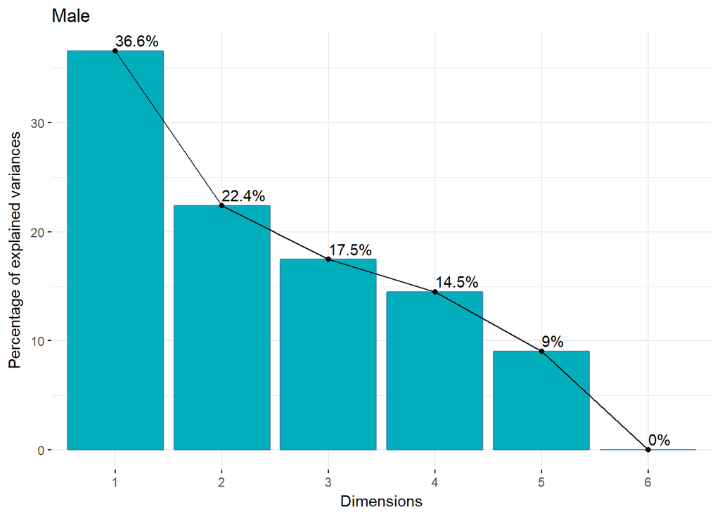

```r
df3 <- subset(df[-c(8,74,82,41),],Sex == 1,select = -Sex)
pca3 <- dudi.pca(df3[,-7],scannf = F,nf = 6)
fviz_eig(pca3,addlabels = T,title = "Male",barfill="#00AFBB")
```

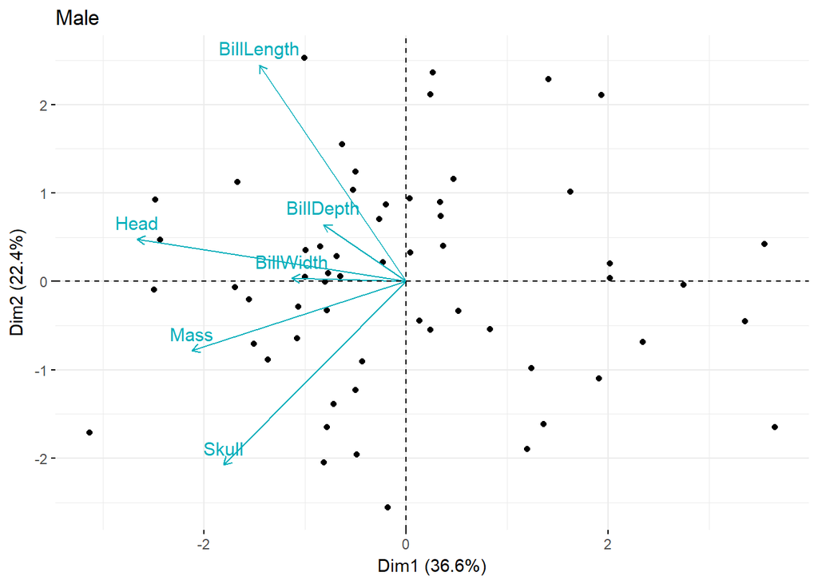

```r
fviz_pca_biplot(pca3,label = "var",title = "Male",col.var = "#00AFBB")
```

Теперь первая компонента объясняет меньше дисперсии, чем раньше.

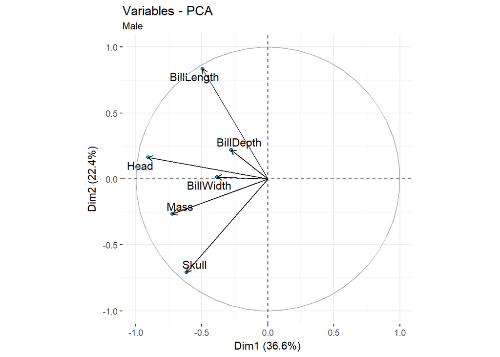

```r
fviz_pca_var(pca3, geom = c("point","arrow","text"),
             pointshape = 21, fill = "#00AFBB", repel=T, subtitle = "Male")
```

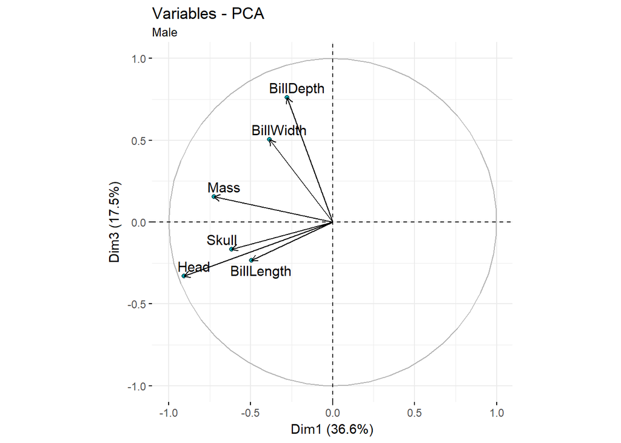

```r
fviz_pca_var(pca3, geom = c("point","arrow","text"),
             pointshape = 21, fill = "#00AFBB", repel=T, axes = c(1,3), subtitle = "Male")
```

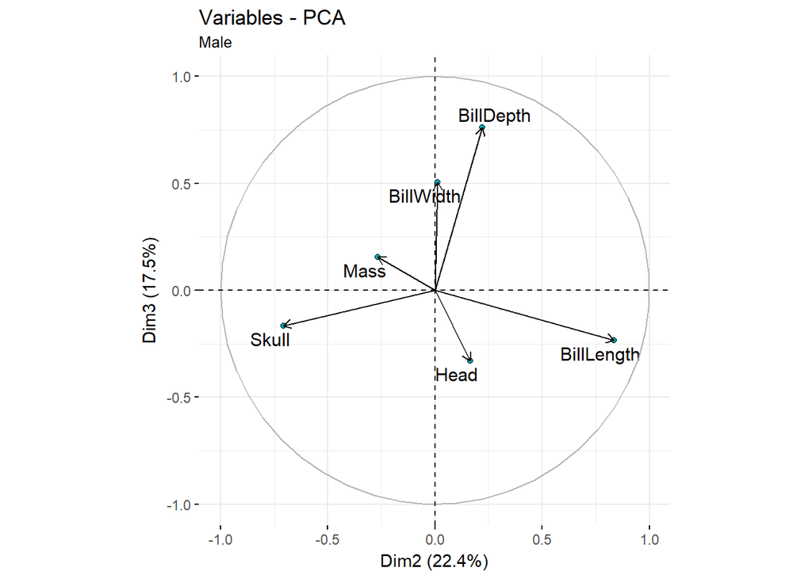

```r
fviz_pca_var(pca3, geom = c("point","arrow","text"),
             pointshape = 21, fill = "#00AFBB", repel=T, axes = c(2,3), subtitle = "Male")
```

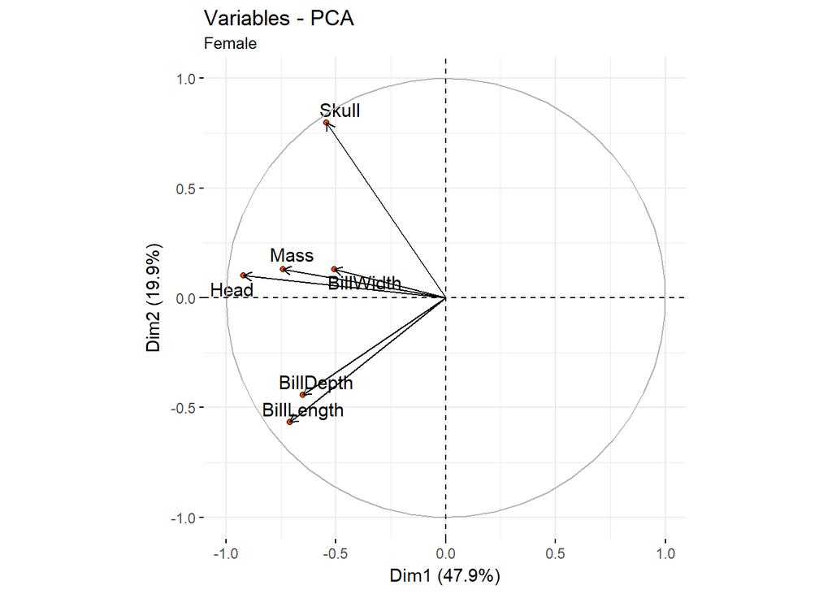

```r
fviz_pca_var(pca4,  geom = c("point","arrow","text"),
             pointshape = 21, fill = "#FC4E07", repel=T, subtitle = "Female")
```

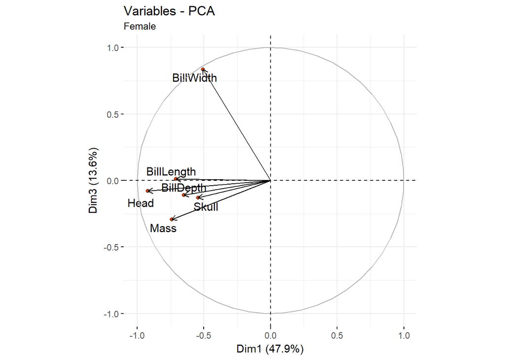

```r
fviz_pca_var(pca4,  geom = c("point","arrow","text"),
             pointshape = 21, fill = "#FC4E07", repel=T, axes = c(1,3), subtitle = "Female")
```

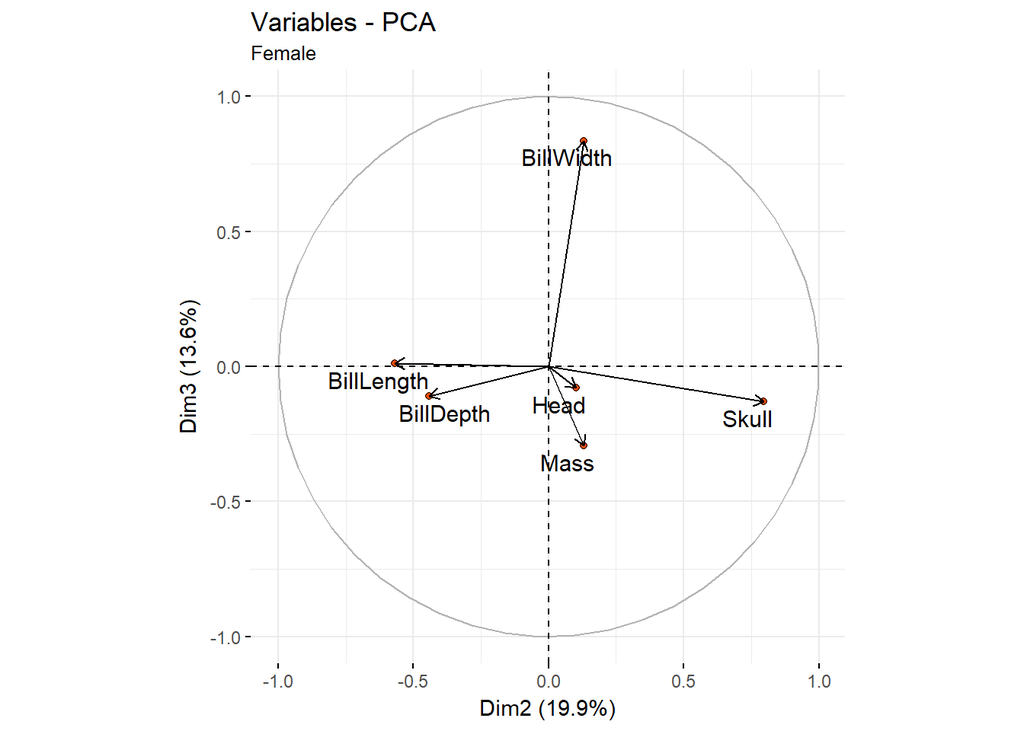

```r
fviz_pca_var(pca4,  geom = c("point","arrow","text"),
             pointshape = 21, fill = "#FC4E07", repel=T, axes = c(2,3), subtitle = "Female")
```

Для мальчиков оказалось, что глубина и ширина клюва практически не вошли в первые две компоненты, то есть носатость птичек описывается в основном длиной клюва. Взглянем на вклады признаков в новые компоненты.

```r
get_pca_var(pca3)$contrib[,1:3]
```

```
##                Dim.1       Dim.2     Dim.3
## BillDepth   3.518220  3.60996793 55.213400
## BillWidth   6.750033  0.01323335 24.238480
## BillLength 11.172300 51.86649658  5.253470
## Head       37.470825  1.98745732 10.408115
## Mass       23.817913  5.26436499  2.287359
## Skull      17.270709 37.25847984  2.599176
```

У девочек можно заметить, что ситуация похожа на случай, когда мы рассматривали всех индивидов сразу.

```r
get_pca_var(pca4)$contrib[,1:3]
```

```
##               Dim.1      Dim.2       Dim.3
## BillDepth  14.68916 16.2802284  1.47454193
## BillWidth   8.97416  1.4171120 85.22015017
## BillLength 17.46384 26.9815745  0.01715597
## Head       29.43987  0.8588086  0.77733808
## Mass       19.14561  1.4221495 10.41517478
## Skull      10.28737 53.0401271  2.09563907
```

Первая компонента показывает размер птичек, вторая – “носатость” (отношение длины клюва и глубины ноздрей к размеру черепа), третья определяет ширину клюва.